# Get base layers

Sean Rohan

5/27/2020

## Get base mapping layers

The get_base_layers() function retrieves shapefiles and other map features that are typically used to make plots of RACE survey areas. The function transforms layers to a user-specified projection based on a coordinate reference system. Alternatively, a default coordinate reference system can be assigned by the function, based on the region.

## Retrieve layers with projection automatically selected

This chunk of code retrieves layers for the EBS shelf survey area and automatically assigns a projection (Albers Equal Area with standard latitudes at 55 °N and 60 °N, cetner latitude 57.5 °N, center longitude at 170 °W **…this is relevant below**). Layers are returned in a list.

```r
library(akgfmaps)

SEBS <- akgfmaps::get_base_layers(select.region = "bs.south", set.crs = "auto")
class(SEBS)
```

```
## [1] "list"
```

```r
names(SEBS)
```

```
##  [1] "akland"        "survey.area"   "survey.strata" "survey.grid"
##  [5] "bathymetry"    "place.labels"  "graticule"     "crs"
##  [9] "plot.boundary" "lon.breaks"    "lat.breaks"
```

## Make a map

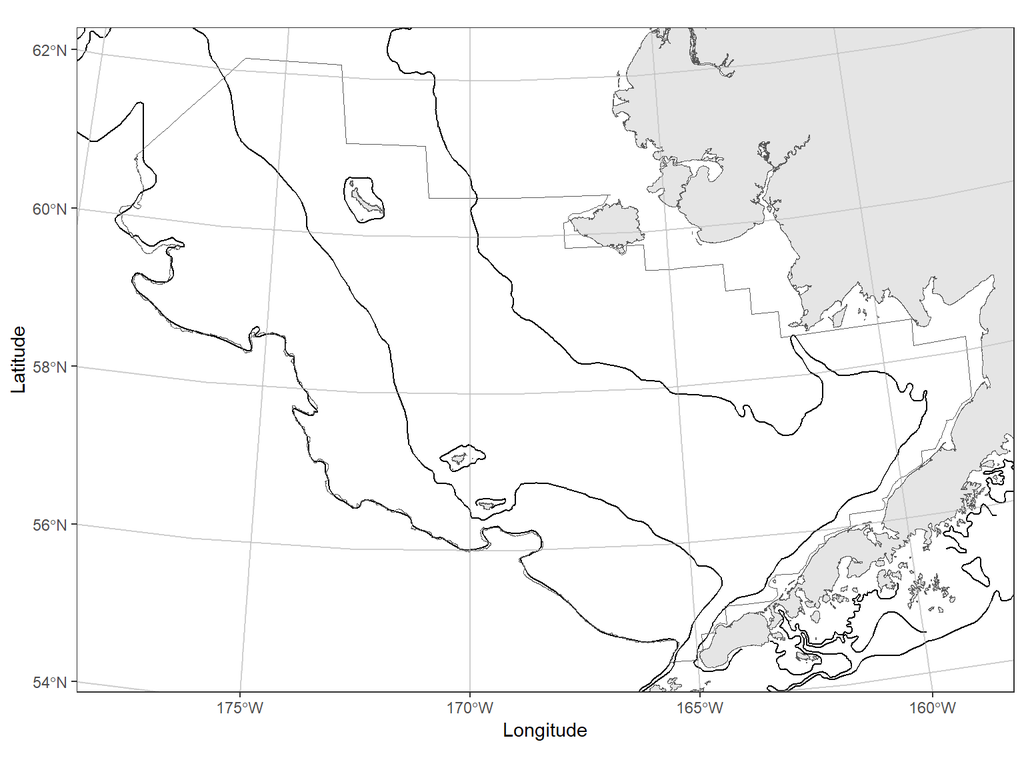

```r
(SEBS_plot <- ggplot() +
  geom_sf(data = SEBS$akland) +
  geom_sf(data = SEBS$bathymetry) +
  geom_sf(data = SEBS$survey.area, fill = NA) +
  geom_sf(data = SEBS$graticule, color = "grey70", alpha = 0.5) +
  coord_sf(xlim = SEBS$plot.boundary$x,
           ylim = SEBS$plot.boundary$y) +
  scale_x_continuous(name = "Longitude",
                     breaks = SEBS$lon.breaks) +
  scale_y_continuous(name = "Latitude",
                     breaks = SEBS$lat.breaks) +
  theme_bw())
```

## Adding your own layers

Although the map shows the x-axis and y-axis as latitude and longitude with degrees, coordinates for all of the layers are in **meters**.

Therefore, adding text to the map at 58 N, 165 W using coordinates x = -165, y = 58 results in a label centered 165 m (longitudinally) and 58 m (latitudinally) away from the center of the projection.

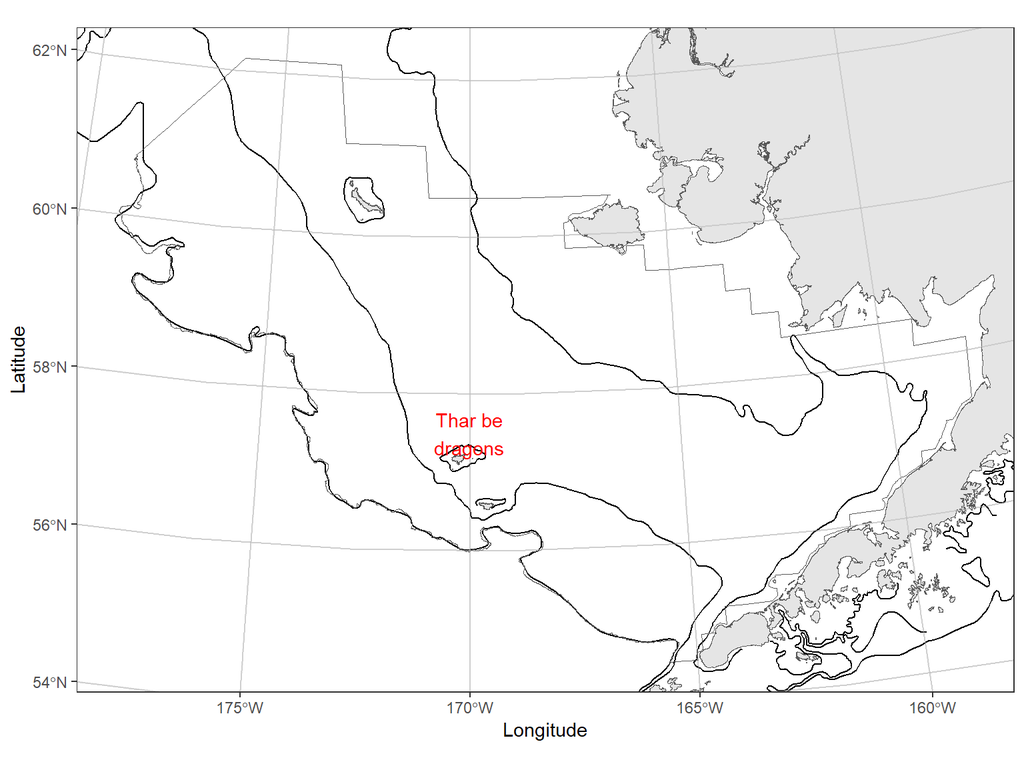

```r
my_label <- data.frame(x = -165, y = 58, label = "Thar be\ndragons")

SEBS_plot + geom_text(data = my_label,
                      mapping = aes(x = x,
                                    y = y,
                                    label = label),
                      color = "red")
```

The akgfmaps package includes a function to convert data frame coordinates to the projection without changing the data frame type.

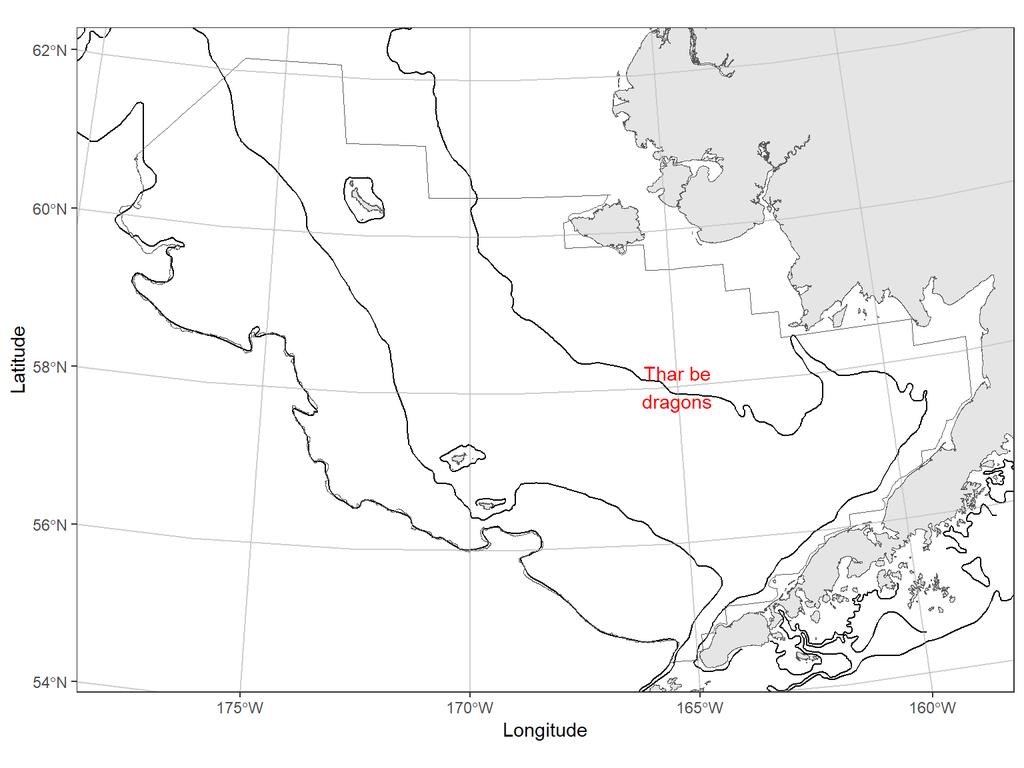

```r
my_label <- data.frame(x = -165, y = 58, label = "Thar be\ndragons") |>
  akgfmaps::transform_data_frame_crs(in.crs = "+proj=longlat", out.crs = SEBS$crs)

SEBS_plot + geom_text(data = my_label,
                      mapping = aes(x = x,
                                    y = y,
                                    label = label),
                      color = "red")
```

## Add labels

Formatted placename labels can be added directly to the plot using akgfmaps::add_map_labels(), although it is suggested to add labels manually to avoid formatting issues.

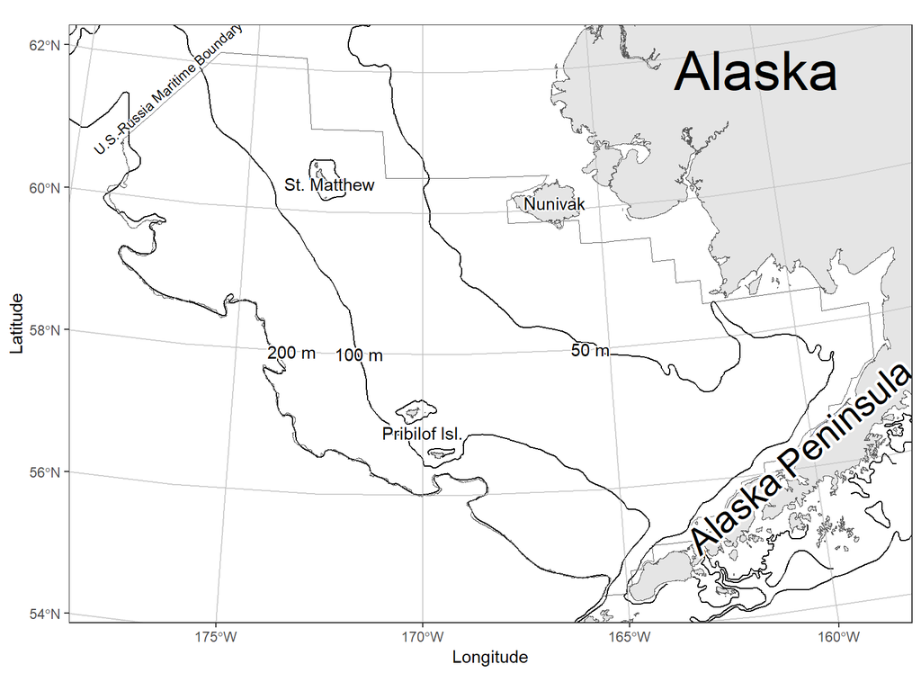

```r
(SEBS_plot |> add_map_labels(region = "bs.south", new.places = SEBS$place.labels))
```